# Academic Performance Analysis

```python
import pandas as pd
import numpy as np
import matplotlib.pyplot as plt
import seaborn as sns
```

# Loading Data

```python
data = pd.read_csv("./dataset/en_lpor_explorer.csv")

print(data.shape)
data.head()
```

```
(649, 31)
```

|  | School | Gender | Age | Housing_Type | Family_Size | Parental_Status | Mother_Education | Father_Education | Mother_Work | Father_Work | ... | Is_Dating | Good_Family_Relationship | Free_Time_After_School | Time_with_Friends | Alcohol_Weekdays | Alcohol_Weekends | Health_Status | School_Absence | Grade_1st_Semester | Grade_2nd_Semester |
| --- | --- | --- | --- | --- | --- | --- | --- | --- | --- | --- | --- | --- | --- | --- | --- | --- | --- | --- | --- | --- | --- |
| 0 | Gabriel Pereira | Female | 18 | Urban | Above 3 | Separated | Higher Education | Higher Education | Homemaker | Teacher | ... | No | Good | Moderate | High | Very Low | Very Low | Fair | 4 | 0 | 11 |
| 1 | Gabriel Pereira | Female | 17 | Urban | Above 3 | Living Together | Primary School | Primary School | Homemaker | other | ... | No | Excellent | Moderate | Moderate | Very Low | Very Low | Fair | 2 | 9 | 11 |
| 2 | Gabriel Pereira | Female | 15 | Urban | Up to 3 | Living Together | Primary School | Primary School | Homemaker | other | ... | No | Good | Moderate | Low | Low | Moderate | Fair | 6 | 12 | 13 |
| 3 | Gabriel Pereira | Female | 15 | Urban | Above 3 | Living Together | Higher Education | Lower Secondary School | Health | Services | ... | Yes | Fair | Low | Low | Very Low | Very Low | Very Good | 0 | 14 | 14 |
| 4 | Gabriel Pereira | Female | 16 | Urban | Above 3 | Living Together | High School | High School | other | other | ... | No | Good | Moderate | Low | Very Low | Low | Very Good | 0 | 11 | 13 |

5 rows × 31 columns

# Exploratory Data Analysis

```python
data.columns
```

```
Index(['School', 'Gender', 'Age', 'Housing_Type', 'Family_Size',
       'Parental_Status', 'Mother_Education', 'Father_Education',
       'Mother_Work', 'Father_Work', 'Reason_School_Choice',
       'Legal_Responsibility', 'Commute_Time', 'Weekly_Study_Time',
       'Extra_Educational_Support', 'Parental_Educational_Support',
       'Private_Tutoring', 'Extracurricular_Activities', 'Attended_Daycare',
       'Desire_Graduate_Education', 'Has_Internet', 'Is_Dating',
       'Good_Family_Relationship', 'Free_Time_After_School',
       'Time_with_Friends', 'Alcohol_Weekdays', 'Alcohol_Weekends',
       'Health_Status', 'School_Absence', 'Grade_1st_Semester',
       'Grade_2nd_Semester'],
      dtype='object')
```

```python
data = data.drop(columns=[
            'Housing_Type',
            'Family_Size',
            'Father_Education',
            'Mother_Education',
            'Father_Work',
            'Mother_Work',
            'Reason_School_Choice',
            'Commute_Time',
            'Extracurricular_Activities',
            'Attended_Daycare',
            'Desire_Graduate_Education',
            'Free_Time_After_School',
            'Time_with_Friends'
                          ])
```

```python
data.info()
```

```
<class 'pandas.core.frame.DataFrame'>
RangeIndex: 649 entries, 0 to 648
Data columns (total 18 columns):
 #   Column                        Non-Null Count  Dtype
---  ------                        --------------  -----
 0   School                        649 non-null    object
 1   Gender                        649 non-null    object
 2   Age                           649 non-null    int64
 3   Parental_Status               649 non-null    object
 4   Legal_Responsibility          649 non-null    object
 5   Weekly_Study_Time             649 non-null    object
 6   Extra_Educational_Support     649 non-null    object
 7   Parental_Educational_Support  649 non-null    object
 8   Private_Tutoring              649 non-null    object
 9   Has_Internet                  649 non-null    object
 10  Is_Dating                     649 non-null    object
 11  Good_Family_Relationship      649 non-null    object
 12  Alcohol_Weekdays              649 non-null    object
 13  Alcohol_Weekends              649 non-null    object
 14  Health_Status                 649 non-null    object
 15  School_Absence                649 non-null    int64
 16  Grade_1st_Semester            649 non-null    int64
 17  Grade_2nd_Semester            649 non-null    int64
dtypes: int64(4), object(14)
memory usage: 91.4+ KB
```

```python
data.isna().sum()
```

```
School                          0
Gender                          0
Age                             0
Parental_Status                 0
Legal_Responsibility            0
Weekly_Study_Time               0
Extra_Educational_Support       0
Parental_Educational_Support    0
Private_Tutoring                0
Has_Internet                    0
Is_Dating                       0
Good_Family_Relationship        0
Alcohol_Weekdays                0
Alcohol_Weekends                0
Health_Status                   0
School_Absence                  0
Grade_1st_Semester              0
Grade_2nd_Semester              0
dtype: int64
```

```python
data.describe(include = "all")
```

|  | School | Gender | Age | Parental_Status | Legal_Responsibility | Weekly_Study_Time | Extra_Educational_Support | Parental_Educational_Support | Private_Tutoring | Has_Internet | Is_Dating | Good_Family_Relationship | Alcohol_Weekdays | Alcohol_Weekends | Health_Status | School_Absence | Grade_1st_Semester | Grade_2nd_Semester |
| --- | --- | --- | --- | --- | --- | --- | --- | --- | --- | --- | --- | --- | --- | --- | --- | --- | --- | --- |
| count | 649 | 649 | 649.000000 | 649 | 649 | 649 | 649 | 649 | 649 | 649 | 649 | 649 | 649 | 649 | 649 | 649.000000 | 649.000000 | 649.000000 |
| unique | 2 | 2 | NaN | 2 | 3 | 4 | 2 | 2 | 2 | 2 | 2 | 5 | 5 | 5 | 5 | NaN | NaN | NaN |
| top | Gabriel Pereira | Female | NaN | Living Together | Mother | 2 to 5h | No | Yes | No | Yes | No | Good | Very Low | Very Low | Very Good | NaN | NaN | NaN |
| freq | 423 | 383 | NaN | 569 | 455 | 305 | 581 | 398 | 610 | 498 | 410 | 317 | 451 | 247 | 249 | NaN | NaN | NaN |
| mean | NaN | NaN | 16.744222 | NaN | NaN | NaN | NaN | NaN | NaN | NaN | NaN | NaN | NaN | NaN | NaN | 3.659476 | 11.399076 | 11.570108 |
| std | NaN | NaN | 1.218138 | NaN | NaN | NaN | NaN | NaN | NaN | NaN | NaN | NaN | NaN | NaN | NaN | 4.640759 | 2.745265 | 2.913639 |
| min | NaN | NaN | 15.000000 | NaN | NaN | NaN | NaN | NaN | NaN | NaN | NaN | NaN | NaN | NaN | NaN | 0.000000 | 0.000000 | 0.000000 |
| 25% | NaN | NaN | 16.000000 | NaN | NaN | NaN | NaN | NaN | NaN | NaN | NaN | NaN | NaN | NaN | NaN | 0.000000 | 10.000000 | 10.000000 |
| 50% | NaN | NaN | 17.000000 | NaN | NaN | NaN | NaN | NaN | NaN | NaN | NaN | NaN | NaN | NaN | NaN | 2.000000 | 11.000000 | 11.000000 |
| 75% | NaN | NaN | 18.000000 | NaN | NaN | NaN | NaN | NaN | NaN | NaN | NaN | NaN | NaN | NaN | NaN | 6.000000 | 13.000000 | 13.000000 |
| max | NaN | NaN | 22.000000 | NaN | NaN | NaN | NaN | NaN | NaN | NaN | NaN | NaN | NaN | NaN | NaN | 32.000000 | 19.000000 | 19.000000 |

```python
data ["Average_Grade"] = data[["Grade_1st_Semester", "Grade_2nd_Semester"]].mean(axis = 1)
```

```python
cat_cols = [
  'School', 'Gender', 'Age',
  'Parental_Status', 'Legal_Responsibility', "Weekly_Study_Time",
  "Alcohol_Weekdays", 'Alcohol_Weekends', 'Health_Status',
  'Extra_Educational_Support', 'Parental_Educational_Support', 'Private_Tutoring',
  'Is_Dating', 'Has_Internet', 'Good_Family_Relationship'
  ]
```

# Visualization of Categorical Data

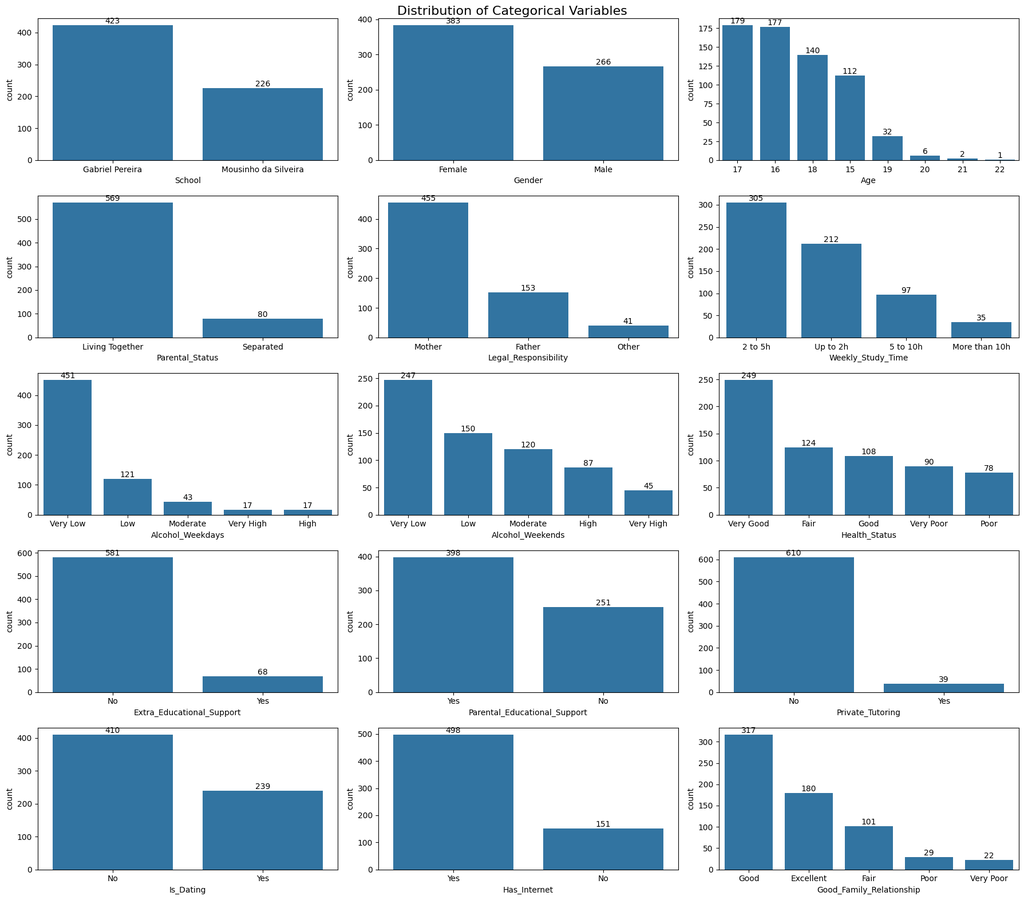

```python
fig, axes = plt.subplots(5,3,
figsize = (18, 16))
fig.suptitle("Distribution of Categorical Variables", fontsize = 16)

for ax, col in zip(axes.flat, cat_cols):
  sns.countplot(
    ax = ax,
    x = col,
    data = data,
    order = data[col].value_counts().index
  )

  for container in ax.containers:
    ax.bar_label(container, fmt= '%d', label_type = 'edge', color = 'black')

  #ax.set_title(col)

plt.tight_layout()
plt.show()
```

The count plots illustrate the frequency distribution of students across different categories. This allows for a better understanding of the demographic and environmental characteristics present in the dataset

Conclusion:

The categorical distributions highlight differences in student backgrounds and support system which may influence academic outcomes

# Calculating Passing Grade

Passing Grade is >=50% (any score >= 10 out of 20)

```python
conditions = [
    (data["Average_Grade"] < 10),
    (data["Average_Grade"] >= 10)
]

values = ["Failed", "Passed"]
data["Pass"] = np.select(conditions, values, default="Unknown")

data.head()
```

|  | School | Gender | Age | Parental_Status | Legal_Responsibility | Weekly_Study_Time | Extra_Educational_Support | Parental_Educational_Support | Private_Tutoring | Has_Internet | Is_Dating | Good_Family_Relationship | Alcohol_Weekdays | Alcohol_Weekends | Health_Status | School_Absence | Grade_1st_Semester | Grade_2nd_Semester | Average_Grade | Pass |
| --- | --- | --- | --- | --- | --- | --- | --- | --- | --- | --- | --- | --- | --- | --- | --- | --- | --- | --- | --- | --- |
| 0 | Gabriel Pereira | Female | 18 | Separated | Mother | 2 to 5h | Yes | No | No | No | No | Good | Very Low | Very Low | Fair | 4 | 0 | 11 | 5.5 | Failed |
| 1 | Gabriel Pereira | Female | 17 | Living Together | Father | 2 to 5h | No | Yes | No | Yes | No | Excellent | Very Low | Very Low | Fair | 2 | 9 | 11 | 10.0 | Passed |
| 2 | Gabriel Pereira | Female | 15 | Living Together | Mother | 2 to 5h | Yes | No | No | Yes | No | Good | Low | Moderate | Fair | 6 | 12 | 13 | 12.5 | Passed |
| 3 | Gabriel Pereira | Female | 15 | Living Together | Mother | 5 to 10h | No | Yes | No | Yes | Yes | Fair | Very Low | Very Low | Very Good | 0 | 14 | 14 | 14.0 | Passed |
| 4 | Gabriel Pereira | Female | 16 | Living Together | Father | 2 to 5h | No | Yes | No | No | No | Good | Very Low | Low | Very Good | 0 | 11 | 13 | 12.0 | Passed |

```python
data["Pass"].value_counts()
```

```
Pass
Passed    478
Failed    171
Name: count, dtype: int64
```

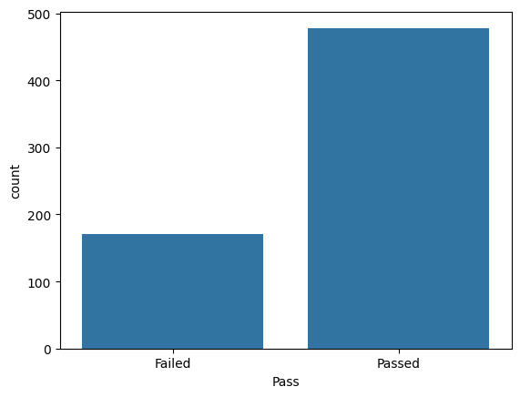

```python
sns.countplot(x = "Pass", data=data)
```

Conclusion:

The count plot of pass and fail outcomes shows the proportion of students who successsfully met the minimum academic requirement compared to those who did not.

# Pass Rate by Categorical Values

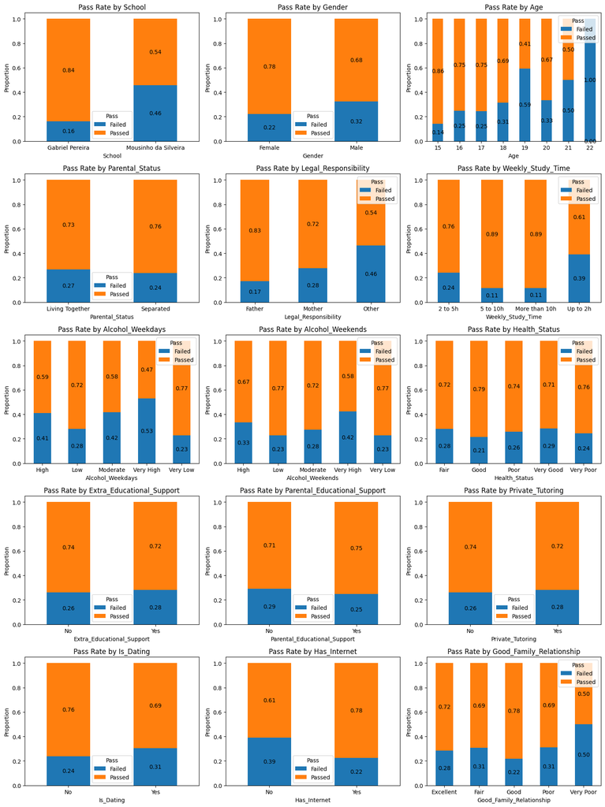

```python
fig, axes = plt.subplots(5,3,
figsize = (15, 20))

for ax, col in zip(axes.flat, cat_cols):
  plot = pd.crosstab(
    data[col],
    data['Pass'],
    normalize="index"
  ).plot(kind="bar", stacked=True, ax=ax)


  for container in plot.containers:
    plot.bar_label(container, fmt= '%.2f', label_type = 'center', color = 'black')

  ax.set_title(f'Pass Rate by {col}')
  ax.set_xlabel(col)
  ax.set_ylabel("Proportion")
  ax.tick_params(axis='x', labelrotation=0)

plt.tight_layout()
plt.show()

plt.show()
```

The chart compares the proportion of students who passed or failed in each school. Differences between schools may reflect variations in educational quality, resources, or teaching methods

Students who reported stronger family relationships were more likely to pass compared to those with weaker family support systems. A supportive family environment can provide emotional encouragement and motivation for academic success

# Multivariate Plots

## Alcohol Consumption × Study Time → Grade

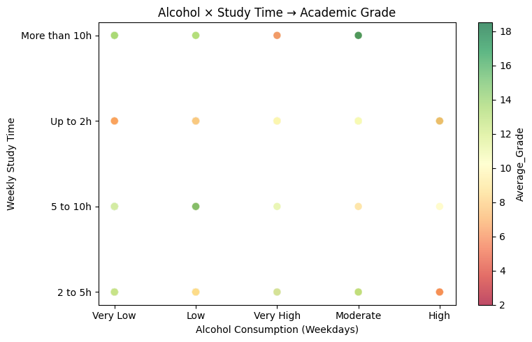

```python
if all(c in data.columns for c in ['Alcohol_Weekdays', 'Weekly_Study_Time', 'Average_Grade']):
    fig, ax = plt.subplots(figsize=(8, 5))
    scatter = ax.scatter(
        data['Alcohol_Weekdays'], data['Weekly_Study_Time'],
        c=data['Average_Grade'], cmap='RdYlGn',
        alpha=0.7, edgecolors='white', linewidths=0.3, s=60
    )
    plt.colorbar(scatter, ax=ax, label='Average_Grade')
    ax.set_xlabel('Alcohol Consumption (Weekdays)')
    ax.set_ylabel('Weekly Study Time')
    ax.set_title('Alcohol × Study Time → Academic Grade')
    plt.tight_layout()
    plt.show()
```

Conclusion:

Higher alcohol consumption is mgenerally associated with lower academic performance, while increased study time tends to correlate with better grades.

## Average Grade — Internet Access x Private Tutoring

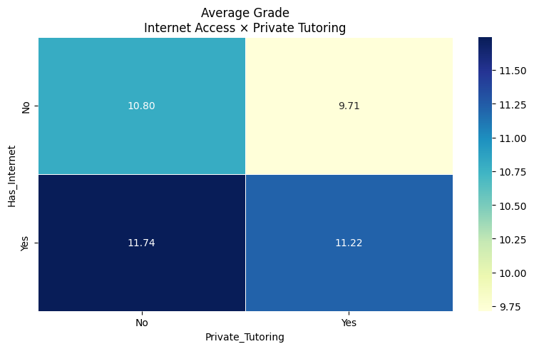

```python
if all(c in data.columns for c in ['Has_Internet', 'Private_Tutoring', 'Average_Grade']):
    pivot = data.pivot_table(
        values='Average_Grade',
        index='Has_Internet',
        columns='Private_Tutoring',
        aggfunc='mean'
    )
    fig, ax = plt.subplots(figsize=(8, 5))
    sns.heatmap(pivot, annot=True, fmt='.2f', cmap='YlGnBu', linewidths=0.5, ax=ax)
    ax.set_title('Average Grade\nInternet Access × Private Tutoring')
    plt.tight_layout()
    plt.show()
```

## Family Relationship × Parental Support → Grade Trajectory

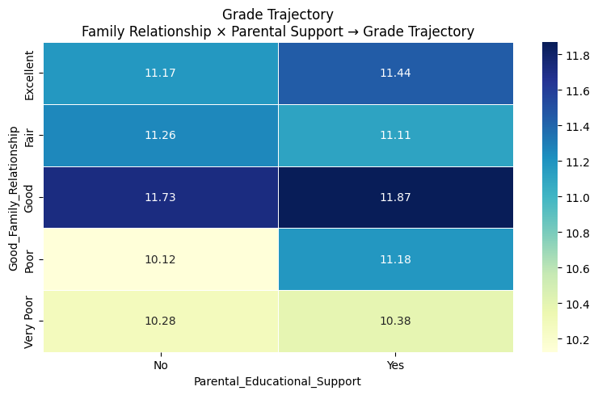

```python
if all(c in data.columns for c in ['Good_Family_Relationship', 'Parental_Educational_Support', 'Average_Grade']):
    pivot = data.pivot_table(
        values='Average_Grade',
        index='Good_Family_Relationship',
        columns= 'Parental_Educational_Support',
        aggfunc='mean'
    )
    fig, ax = plt.subplots(figsize=(8, 5))
    sns.heatmap(pivot, annot=True, fmt='.2f', cmap='YlGnBu', linewidths=0.5, ax=ax)
    ax.set_title('Grade Trajectory\nFamily Relationship × Parental Support → Grade Trajectory')
    plt.tight_layout()
    plt.show()
```

Conclusion:

Students with strong family relationships and active parental educational support generally achieve higher average grades. Parental involvement may encourage better study habits and academic motivation.

# Note: